Home > Unsupervised Learning > Clustering > EM-Clustering

# 3.2.2 EM-Clustering

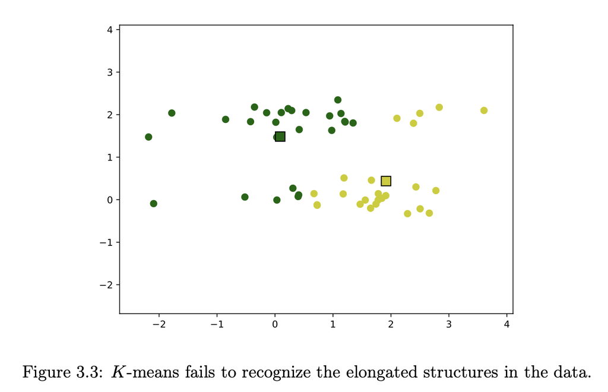

To address the difficulties mentioned in the last chapter with the $K$-means algorithm, we consider a stochastic approach. We assume that the data is distributed according to a Gaussian Mixture Model, i.e. that the points of a cluster are normally distributed around a mean $m_k$. In mathematical terms, this means that the data of the $k$-th group $C_k$ has a density function of the form

#### 3.2.9

$$p_k(x) := \frac{1}{\sqrt{(2\pi)^d
\text{det}\Sigma_k}}\text{exp}\biggl(-\frac{1}{2}(x - m_k)^T
\Sigma_k^{-1}(x-m_k)\biggl), \hspace{0.5cm} x \in \mathbb{R}^d$$
where $m_k \in \mathbb{R}^d$ is a mean of cluster $k$ and $\sum_{k} \in \mathbb{R}^{d \times d}$ is a covariance matrix for $k = 1,..., K$ (describes shape and spread of the cluster). $(x-m_k)^T \sum_{k}{^{-1}}(x-m_k)$ measures the **Mahalanobis** distance, which generalizes Euclidian distance by considering correlations between variables. $\frac{1}{\sqrt{(2\pi)^d \text{det}\sum_k}}$ normalizes the Gaussian function so that the probability integrates to 1 Note that in constrast to Section 2.2.1, we must work with multivariate normal distributions here. In the case of $d=1$ and for $\sum_k := \sigma_k^2$ (3.2.9) simplifies to the familiar density of a scalar normal distribution with mean $m_k \in \mathbb{R}$ and variance $\sigma^2_k$:
$$p_k(x) =
\frac{1}{\sqrt{2\pi\sigma^2_k}}\text{exp}\biggl(-\frac{(x-m_k)^2}{2\sigma^2_k}\biggl)$$
The distribution of all data can then be modeled by a density function of the form (Instead of a single Gaussian function, the whole dataset is modeled as a **mixture** of multiple Gaussian distributions)

#### 3.2.10

$$p(x) := \sum_{k=1}^K \pi_k p_k(x),
\hspace{0.5cm} x \in \mathbb{R}^d$$
where $0 \leq \pi_k \leq 1$ with $\sum_{k=1}^K \pi_k = 1$.

##### Explanation

- $\pi_k$
  - These are the **mixing coefficients**, representing the probability that a randomly chosen data point belongs to cluster $k$
  - They must satisfy $0 \leq \pi_k \leq 1$ and sum to 1!
- $p_k(x)$
  - The probability density function for cluster $k$ Thus the full data distribution $p(x)$ is a weighted sum of **individual** Gaussian distributions, where each cluster contributes proportionally to its prior probability $\pi_k$

As in Bayesian classification, the numbers $\pi_k$ represent the probabilities of the $k$-th group $C_k$. Our goal is to calculate the means $m_k$, the covariance matrices $\sum_k$, and the group probabilities $\pi_k$ by utilizing the data

For this purpose, the so-called *responsibilities* (determine probability that point $x$ belongs to cluster $k$) of the $k$-th group for the point $x$, denoted as $\gamma(x, k)$ are helpful. These are defined as

#### 3.2.11

$$\gamma(x, k) := \mathbb{P}(C_k | x) =
\frac{\pi_k p_k(x)}{p(x)} = \frac{\pi_k p_k(x)}{\sum_{k=1}^K \pi_k
p_k(x)}$$
where we have used Bayes’ theorem for densities.

##### Exkurs

$$\mathbb{P}(C_k |x) = \frac{\mathbb{P}(x
| C_k) \mathbb{P}(C_k)}{\mathbb{P}(x)}$$

- $\mathbb{P}(x |C_k) \rightarrow p_k(x)$:
  - The likelihood of observing the point $x$ given that it belongs to cluster $C_k$. Modeled as Gaussian distribution for cluster $k$
- $\mathbb{P}(C_k) \rightarrow \pi_k$
  - The prior probability of cluster $k$, representing the proportion of data expected in cluster $k$
- $\mathbb{P}(x) \rightarrow p(x)$
  - The total probability of observing $x$ across **all clusters**, which serves as the denominator

#### Explanation

The numerator $\pi_k p_k(x)$ represents the probability that $x$ belongs to cluster $k$, considering the prior $\pi_k$ and the likelihood $p_k(x)$ The denominator is
$$p(x) = \sum_{k=1}^K \pi_k p_k (x)$$
This means that $p(x)$ is the weighted sum of the likelihoods of $x$ under each cluster, weighted by their respective priors $\pi_k$

The so-called EM (Expectation Maximization) algorithm now starts from an initial initialization of the parameters $\pi_k, m_k, \sum_k$ and updates these using the following rules:

#### Initialization

Basically figure out the square or space you are in and either place points randomly or if you have two clusters, you compute a mean point, and pertubate this point into two points then and thus initialize the parameters. Elsewise often K-Means is just used for initialization

First, we define a kind of weight for the $k$-th group as the sum of $\gamma(x, k)$ over all data points via

#### 3.2.12

$$N(k) \leftarrow \sum_{i=1}^N \gamma(x_i,
k)$$
**Explanation**: weight for $k$-th group is calculated by summing the responsibilities for each point $x_i$ with respect to cluster $k$. $N(k)$ is the total weight assigned to cluster $k$, based on how much each point belongs to that cluster. Remember $\gamma(x_i, k)$ is the **responsibility**, which indicates the probability that the point $x_i$, belongs to cluster $k$.

We can now update the group probabilities $\pi_k$ by

#### 3.2.13

$$\pi_k \leftarrow \frac{N(k)}{N}$$
**Explanation**: update prior probability for each cluster. $N$ is the total number of data points, $N(k)$ is the sum of responsibilities for the $k$-th cluster (see above!)

Next, we update the means through a weighted average of the points, where the weights are the responsibilities

#### 3.2.14

$$m_k \leftarrow \frac{1}{N(k)}
\sum_{i=1}^N \gamma(x_i, k)x_i \in \mathbb{R}^d$$
Thus, the points contribute significantly to the $k$-th mean for which the $k$-th group has a large responsibility. (Points that have a higher responsibility for cluster $k$ will have more influence on the new mean of that cluster).

Finally, we update the covariance matrices using a weighted empirical covariance matrix:

#### 3.2.15

$$\Sigma_k \leftarrow \frac{1}{N(k)}
\sum_{i=1}^N \gamma(x_i, k)(x_i-m_k)(x_i-m_k)^T \in \mathbb{R}^{d \times
d}$$

##### Explanation

The covariance matrix is updated to reflect the spread of the data points around the new mean for each cluster, weighted by their responsibilities, where $(x_i - m_k)$ is the vector of deviations from the mean point for $x_i$. Multiplying this with its transposed form gives a covariance matrix! This is then weighed by the responsibility. We divide by the total effective weight of cluster $k$ because this normalizes the sum, resulting in the **weighted empirical covariance matrix** for cluster $k$

An iteration of the EM algorithm thus executes the steps 3.2.12 to 3.2.15 for all $k = 1,.., K$. In the next iteration, the responsibilities $\gamma(x,k)$ defined in 3.2.11 are calculated using the updated parameters of the Gaussian Mixture Model. This is iterated for a fixed number of iterations or until the parameters change only slightly. See figure below:

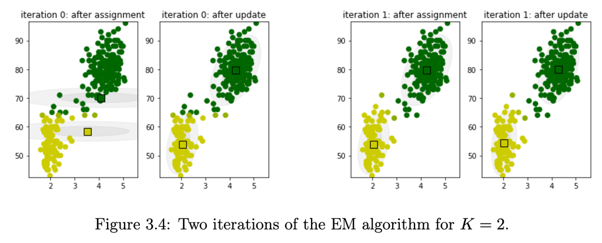

The main difference between $K$-means and EM lies in the covariance matrices $\Sigma_k$, which allow the algorithm to adapt locally to the data, similar to what we observed in principal component decomposition. It should also be noted that the vector ($\gamma(x, k))^K_{k=1}$ is the sought probability vector that contains the group probabilities for a fixed data point $x \in \mathbb{R}^d$

Next up: 3.2.3 Spectral Clustering